# Praca Domowa 4

### Bartosz Siński Winiarze

W poniższej pracy domowej wyliczymy permutacyjną ważność zmiennych dla naszego głównego modelu opartego na wytrenowanym XGBoost. Porównamy także wyniki z modelami opartymi na innych klasyfikatorach wcześniej przez nas wytrenowanych. Przy wyjasnieniach lokalnych mój zespół wyliczył także uśrednione wartości SHAP dla całego modelu. Porównamy więc wpływy zmiennych dla obu tych metod.

```python
import pandas as pd
import numpy as np
import dalex as dx
import shap
import pickle
np.random.seed = 42
```

### Wczytanie modeli i danych, podział na zbiory treningowe i testowe, przygotowanie expleinerów

```python
df_wines = pd.read_csv('./src/winequality-red.csv')
df_wines["is_good"]=df_wines.apply(lambda row: 1 if row.quality > 5 else 0, axis = 1)
X = df_wines.drop(columns = ['quality','is_good'])
y = df_wines[['is_good']]
from sklearn.model_selection import train_test_split
X_train, X_test, y_train, y_test = train_test_split(X, y, random_state = 42)
```

```python
xgb = pickle.load(open('xgboost.sav', 'rb'))
xgb.fit(X_train,y_train)
```

```
RandomizedSearchCV(cv=4,
                   estimator=XGBClassifier(base_score=None, booster=None,
                                           colsample_bylevel=None,
                                           colsample_bynode=None,
                                           colsample_bytree=None,
                                           eval_metric='logloss', gamma=None,
                                           gpu_id=None, importance_type='gain',
                                           interaction_constraints=None,
                                           learning_rate=None,
                                           max_delta_step=None, max_depth=None,
                                           min_child_weight=None, missing=nan,
                                           monotone_constraints=...
                                           reg_lambda=None,
                                           scale_pos_weight=None, seed=42,
                                           subsample=None, tree_method=None,
                                           use_label_encoder=False,
                                           validate_parameters=None,
                                           verbosity=None),
                   n_iter=1000,
                   param_distributions={'colsample_bytree': [0.3, 0.4, 0.5,
                                                             0.7],
                                        'gamma': [0.0, 0.1, 0.2, 0.3, 0.4],
                                        'learning_rate': [0.05, 0.1, 0.15, 0.2,
                                                          0.25, 0.3],
                                        'max_depth': [3, 4, 5, 6, 8, 10, 12,
                                                      15],
                                        'min_child_weight': [1, 3, 5, 7]})
```

```python
svm = pickle.load(open('svm.sav', 'rb'))
svm.fit(X_train,y_train)
```

```
A column-vector y was passed when a 1d array was expected. Please change the shape of y to (n_samples, ), for example using ravel().
```

```
GridSearchCV(cv=4, estimator=SVC(random_state=42), n_jobs=2,
             param_grid=[{'C': [2000, 4000, 6000, 8000, 10000, 12000, 14000,
                                16000, 18000, 20000],
                          'gamma': [0.0002, 0.0004, 0.0006, 0.0008, 0.001,
                                    0.0012, 0.0014, 0.0016, 0.0018, 0.002],
                          'kernel': ['rbf']}],
             scoring='accuracy')
```

```python
random_forest = pickle.load(open('random_forest.sav', 'rb'))
random_forest.fit(X_train,y_train)
```

```
Fitting 4 folds for each of 180 candidates, totalling 720 fits
```

```
A column-vector y was passed when a 1d array was expected. Please change the shape of y to (n_samples,), for example using ravel().
```

```
GridSearchCV(cv=4, estimator=RandomForestClassifier(random_state=1613),
             n_jobs=-1,
             param_grid={'bootstrap': [True], 'max_depth': [75, 80, 85, 90],
                         'max_features': ['auto'],
                         'min_samples_leaf': [1, 2, 4],
                         'min_samples_split': [2, 3, 4],
                         'n_estimators': [900, 950, 1000, 1050, 1100]},
             verbose=2)
```

```python
explainer_xgb = dx.Explainer(xgb, X_train, y_train,label="XGBoost")
explainer_svm = dx.Explainer(svm, X_train, y_train,label="SVM")
explainer_rf = dx.Explainer(random_forest, X_train, y_train,label="Random Forest")
```

[output not shown]

### Permutacyjna ważność zmiennych dla modelu XGBoost

```python
fxgb = explainer_xgb.model_parts()
fxgb.result
```

|  | variable | dropout_loss | label |
| --- | --- | --- | --- |
| 0 | _full_model_ | 0.000000 | XGBoost |
| 1 | residual sugar | 0.000133 | XGBoost |
| 2 | fixed acidity | 0.000201 | XGBoost |
| 3 | density | 0.000414 | XGBoost |
| 4 | pH | 0.000414 | XGBoost |
| 5 | free sulfur dioxide | 0.000447 | XGBoost |
| 6 | citric acid | 0.002095 | XGBoost |
| 7 | chlorides | 0.003339 | XGBoost |
| 8 | volatile acidity | 0.003463 | XGBoost |
| 9 | total sulfur dioxide | 0.006339 | XGBoost |
| 10 | alcohol | 0.023427 | XGBoost |
| 11 | sulphates | 0.045306 | XGBoost |
| 12 | _baseline_ | 0.498113 | XGBoost |

```python
fxgb.loss_function
```

```
<function dalex.model_explanations._variable_importance.loss_functions.loss_one_minus_auc(observed, predicted)>
```

```python
fxgb.plot()
```

[interactive chart not shown]

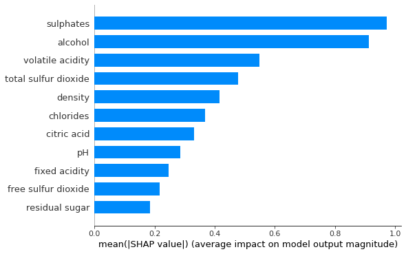

```python
xgb_model = xgb.best_estimator_
shap.summary_plot(shap.TreeExplainer(xgb_model).shap_values(X_train),X_train, plot_type="bar")
```

### Porównanie ważnośći zmiennych pomiędzy różnymi modelami.

```python
fsvm = explainer_svm.model_parts()
frf = explainer_rf.model_parts()
```

```python
fxgb.plot([fsvm,frf])
```

[interactive chart not shown]

Na zbiorze treningowym Radnom Forest i Xgboost osiągnęły maksymalną wartość AUC. W SVM prawie dla każdej zmiennej permutacja obserwacji obniżała jakość predykcji bardziej niż w pozostałych modelach. Jedynym wyjątkiem okazała się być zawartośc soli (chlorides) i gęstość (density), dla których permutacje prawie nie zmieniły wartości funkcji straty. Ciekawa w SVM wydaje się być także waga cząsteczek siarki (free sulfur dioxide), która była zdecydowanie wyższa niż w pozostałych modelach. Wszystkie modele różnią się także pod wzgledem kolejności najważniejszych zmiennych. Tylko XGBoost nie uznał jako najważniejszej zmiennej alkoholu.

### Wnioski

Przy wyliczaniu permutacyjnej ważności zmiennych dla XGBoost najbardziej zdziwiło nas to, że zawartość siarczanów (sulphates) była najważniejsza. Wcześniejsze wyjaśnienia lokalne wskazywały, że najważniejszy będzie alkohol. Następnie zobaczyliśmy, że wpływy zmiennych pomiędzy naszymi modelami bardzo się różniły. Sposród trzech najbardziej odstawał SVM, który potrafił przypisać zarówno wyższe (free sulfur dioxide), jak i niższe (chlorides) wartości zmiennym niż pozostałe modele. SVM był także najbardziej wrażliwy na permutacje obserwacji. Funkcja straty wybranego przez nas XGBoosta z drugiej strony zmieniała się najmniej.